# EDA about profile

# 1 introduction

このレポートはアンケートデータ

- profile_data
- profile_master

についての概観を行うものである．

本節では，アンケートデータについての概要と構成について述べる．  
次節では各アンケート分類ごとに，主要なアンケートに絞って集計・可視化を行う

## 1.1 question genre

アンケートの質問は`qu_genre`で大まかに分類される

私見では，役に立つのは 1 ~ 11, 25, 32 ぐらい．それ以外は使いにくい

| qu_genre_code | qu_genre | 質問数 |
| --- | --- | --- |
| 1 | フェース項目（基本特性以外） | 16 |
| 2 | 普段の生活行動 | 2 |
| 3 | 意識項目 | 163 |
| 4 | メディア関連項目＜接触頻度＞ | 12 |
| 5 | メディア関連項目＜接触時間量＞ | 18 |
| 6 | テレビ関連項目 | 10 |
| 7 | テレビ関連項目（BS・CS・専門チャンネル） | 13 |
| 8 | 動画配信サービス | 2 |
| 9 | 新聞関連項目 | 17 |
| 10 | 雑誌関連項目 | 4 |
| 11 | インターネット関連項目 | 56 |
| 12 | 通信販売・オンラインショッピング・ネットスーパー・食材宅配サービス | 40 |
| 13 | 商品・サービス関連 | 77 |
| 14 | ミネラルウォーター飲用状況 | 5 |
| 15 | お茶飲用状況 | 5 |
| 16 | スポーツドリンク・機能性飲料飲用状況 | 5 |
| 17 | 缶コーヒー飲用状況 | 5 |
| 20 | ビール飲用状況 | 5 |
| 21 | 発泡酒飲用状況 | 5 |
| 22 | 新ジャンル飲料飲用状況 | 5 |
| 23 | 乗用車関連 | 6 |
| 25 | クラスター分類（ＶＲ区分） | 7 |
| 27 | コンビニコーヒー | 5 |
| 32 | SNS関連項目 | 6 |

### 1.1.1 Overview

各アンケート分類についての概観

1. フェース項目：世帯の物理特性について（家族構成，経済状況）
2. 生活行動：起床在宅時間
3. 意識項目：人生観，価値観について（**メディア関係のものが含まれる**）
4. メディア関連項目（頻度）：メディアに触れる頻度（テレビ・スマホ・タブレット・PC・PHS・新聞・雑誌・電車・チラシ・ラジオ）
5. メディア関連項目（時間）：メディアに触れる時間（同上）
6. テレビ関連項目：各放送局のイメージ and 好きなジャンル・放送局について
7. テレビ関連項目（BS・CS・専門チャンネル）：各BS・CSの加入期間 and 視聴可能チャンネルについて
8. 動画配信サービス：動画配信サービスの利用や認知について（Youyube, Hulu, Abema）
9. 新聞関連項目：何の新聞を読んでいるかについて（曜日・朝刊夕刊ごと）
10. 雑誌関連項目：どのぐらいの頻度で雑誌を読むか，何を読むか（週刊，隔週刊，月刊）
11. インターネット関連項目：アプリごとに，どのぐらいの頻度で利用するか(SNS，ゲーム，動画配信等)
12. 通販関連：通販の利用頻度や購入メディア
13. 商品・サービス関連：日々の購買についていろいろ
- クラスター分類：**ビデオリサーチが提供するナゾのクラスタ**．おそらく**意識項目**を元にVRが独自に作成．
- SNS関連項目：SNS利用方法・頻度（Facebook, Twitter, Instagram）

## 1.2 question type

本アンケートには自由記述式がないが，単回答式と複数回答式が存在する． それぞれの注意点について簡単に述べる

### 1.2.1 single answer

基本的に普通に集計するだけでよい．項目ごとに

- 回答数
- 総計に対する比率

を集計する．

### 1.2.2 multi answer

一人で複数項目を選択できる．そのため単回答式と同じ集計を行うとまずい  
具体的には，多く選択する人の影響が大きくなる．そのため

- 回答数
- 回答者数のうち何人が回答したか

を集計するのがのぞましい

**円グラフは絶対に使わない**

# 2 summarise

ここからは，面白そうな質問に限って紹介していく

## 2.1 SNS関連項目

- instagramは他に比べて利用者に偏りがある．若干知名度が低い
- Twitterは他に比べて1日数回以上利用する人が多い
- Facebookは利用していてもたまにしか利用しない人が多い

### 2.1.1 frequency of use

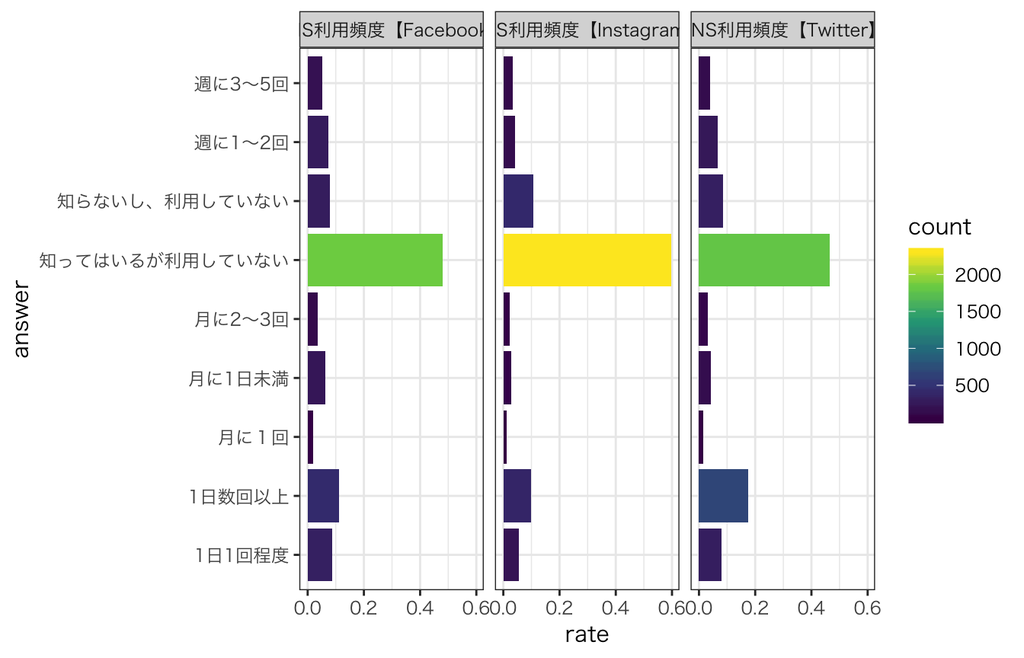

```r
data %>%
  filter(qu_genre_code == 32,
         question_type == "SA") %>%
  group_by(question, answer) %>%
  summarise(count = n()) %>%
  mutate(rate = count / sum(count)) %>%
  ggplot(aes(answer, rate, fill = count))+
  geom_bar(stat = "identity")+
  facet_wrap(~question)+
  coord_flip()+
  scale_fill_viridis_c()
```

### 2.1.2 how to use

- 「いいね！」，「拡散」に顕著な差（Twitterが異質）
- それ以外の項目に関しては若干の特徴が出る感じ

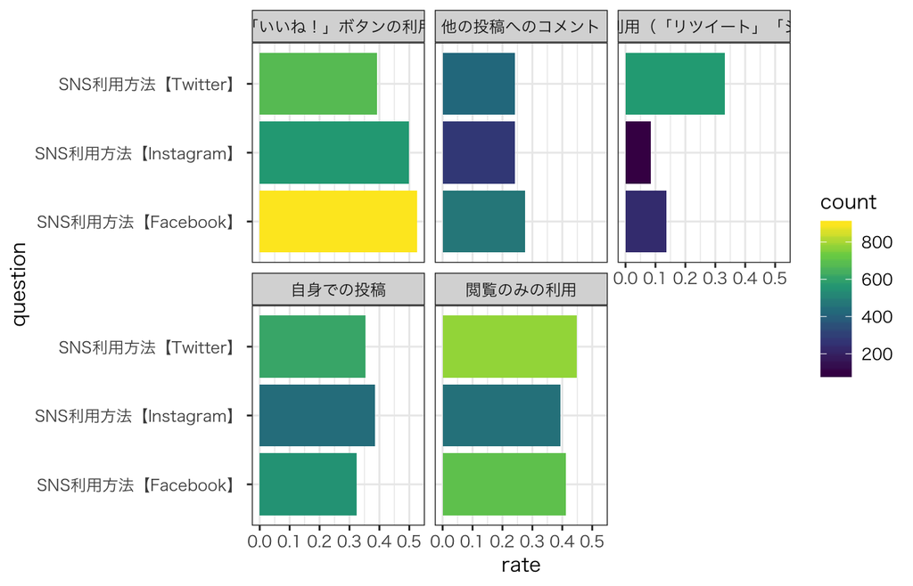

```r
data %>%
  filter(qu_genre_code == 32,
         question_type == "MA") %>%
  group_by(question, house_num) %>%
  summarise() %>%
  summarise(count_house = n()) %>%
  left_join(data, by = "question") %>%
  group_by(question, answer) %>%
  summarise(count = n(),
            count_house = count_house[1]) %>%
  mutate(rate = count / count_house) %>%
  ggplot(aes(question, rate, fill = count))+
  geom_bar(stat = "identity")+
  scale_fill_viridis_c()+
  facet_wrap(~answer)+
  coord_flip()
```

## 2.2 クラスター分類（VR区分）

ビデオリサーチにより提供される謎のクラスタ  
なんと大々的にやっているらしい．[参考リンク](http://vrhitoseg.com/results/)  
しかも自分の16個の質問に答えるだけで分類してくれるよ！！[参考リンク](http://vrhitoseg.com/)  
既にクラスタリングした結果であるので，素直に受け入れて使うのがいいかもしれない

1. 情報×選択セグメント：本参照
2. 表現嗜好セグメント：（[参考](https://www.videor.co.jp/vr-digest/pdf/vrd522_201211/vrd522_article2.pdf)）
3. シニアセグメント：シニア時代の人生観（[参考](https://dentsu-ho.com/articles/4963)）
4. イノベーター指標：新商品やこれから来るブームに対する感応度（[参考](https://www.jmrlsi.co.jp/knowledge/yougo/my02/my0219.html)）
5. 将来観：招来観，ようわからん
6. わかものパーソナリティ：若者の人生観・社会性（[参考](https://www.videor.co.jp/vr-digest/pdf/vrd552_20160708/vrd552_article1.pdf)）
7. 調理性向クラスター：主婦の調理に対する態度（[参考](https://www.videor.co.jp/vr-digest/pdf/vrd531_201311/vrd531_article5.pdf)）

### 2.2.1 information selection

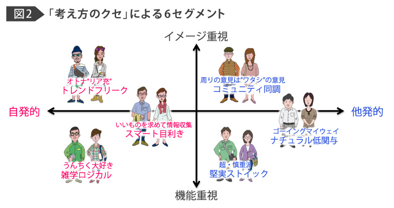

情報選択セグメント

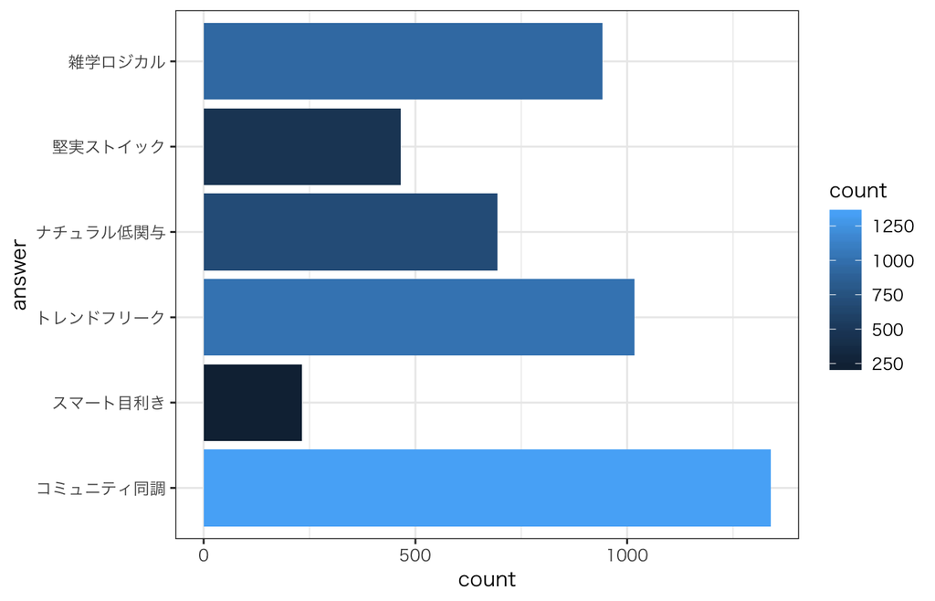

```r
data %>%
  filter(qu_genre_code == 25,
         question_code == 1) %>%
  group_by(answer) %>%
  summarise(count = n()) %>%
  mutate(rate = count / sum(count)) %>%
  ggplot(aes(answer, count, fill = count))+
  geom_bar(stat = "identity")+
  coord_flip()
```

### 2.2.2 expression perference

CMの感じ取り方？？

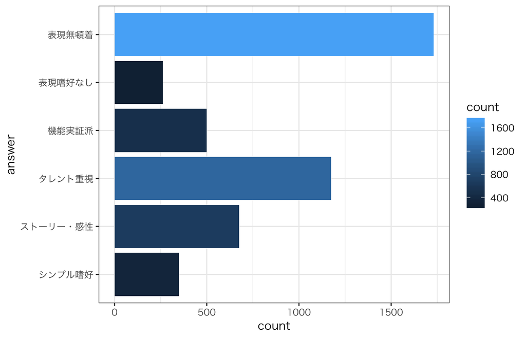

```r
data %>%
  filter(qu_genre_code == 25,
         question_code == 2) %>%
  group_by(answer) %>%
  summarise(count = n()) %>%
  mutate(rate = count / sum(count)) %>%
  ggplot(aes(answer, count, fill = count))+
  geom_bar(stat = "identity")+
  coord_flip()
```

### 2.2.3 Senior

[figure not shown]

シニアセグメント

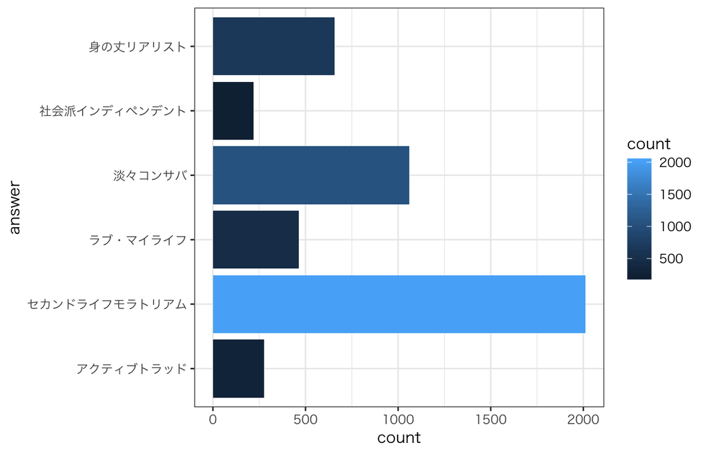

```r
data %>%
  filter(qu_genre_code == 25,
         question_code == 3) %>%
  group_by(answer) %>%
  summarise(count = n()) %>%
  mutate(rate = count / sum(count)) %>%
  ggplot(aes(answer, count, fill = count))+
  geom_bar(stat = "identity")+
  coord_flip()
```

### 2.2.4 Innovator

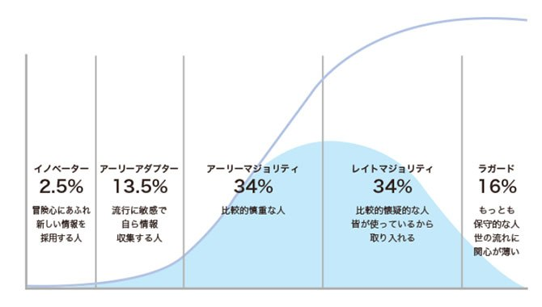

出展：https://i1.wp.com/connect-material.com/wp-content/uploads/2018/02/innovator.jpg?w=670&ssl=1

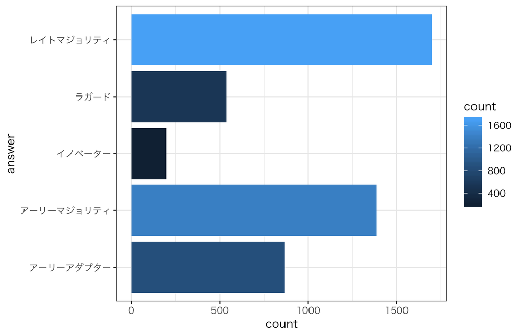

```r
data %>%
  filter(qu_genre_code == 25,
         question_code == 4) %>%
  group_by(answer) %>%
  summarise(count = n()) %>%
  mutate(rate = count / sum(count)) %>%
  ggplot(aes(answer, count, fill = count))+
  geom_bar(stat = "identity")+
  coord_flip()
```

### 2.2.5 vision of the future

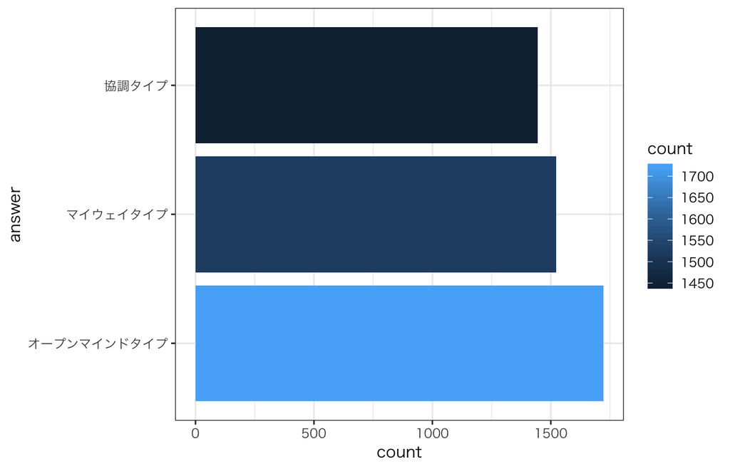

```r
data %>%
  filter(qu_genre_code == 25,
         question_code == 5) %>%
  group_by(answer) %>%
  summarise(count = n()) %>%
  mutate(rate = count / sum(count)) %>%
  ggplot(aes(answer, count, fill = count))+
  geom_bar(stat = "identity")+
  coord_flip()
```

### 2.2.6 Junior

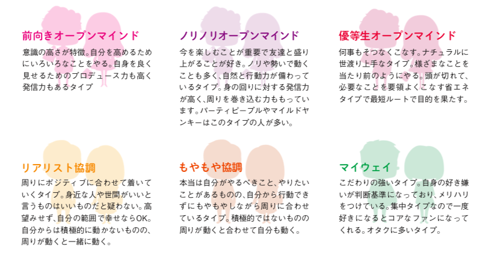

わかものパーソナリティ

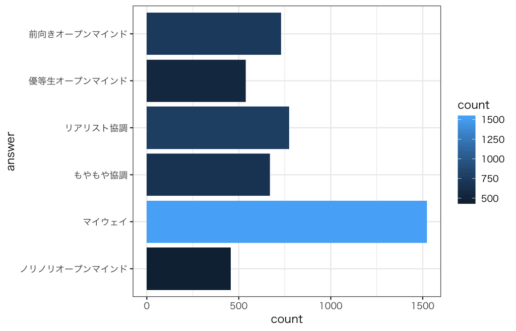

```r
data %>%
  filter(qu_genre_code == 25,
         question_code == 6) %>%
  group_by(answer) %>%
  summarise(count = n()) %>%
  mutate(rate = count / sum(count)) %>%
  ggplot(aes(answer, count, fill = count))+
  geom_bar(stat = "identity")+
  coord_flip()
```

### 2.2.7 Cooking

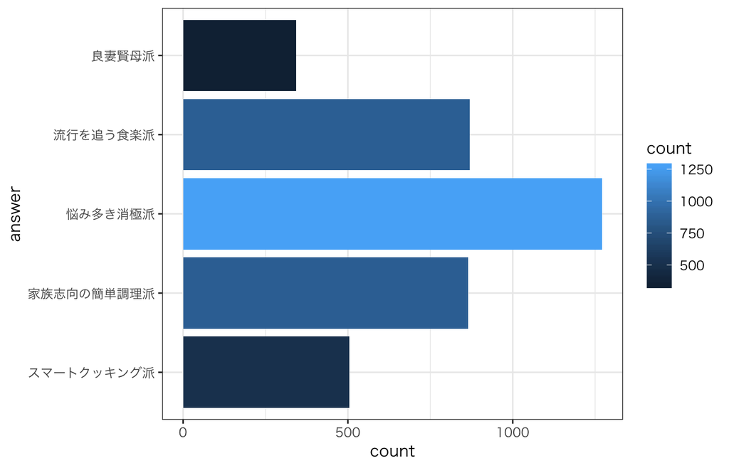

```r
data %>%
  filter(qu_genre_code == 25,
         question_code == 7) %>%
  group_by(answer) %>%
  summarise(count = n()) %>%
  mutate(rate = count / sum(count)) %>%
  ggplot(aes(answer, count, fill = count))+
  geom_bar(stat = "identity")+
  coord_flip()
```

## 2.3 普段の生活行動

起床在宅時間（家にいてかつ活動できる時間）に関する質問

- 普段の起床在宅時間帯（平日）：MA
- 普段の起床在宅時間帯（土日）：MA

- 平日は早起きして日中は家にいない
- 土日も昼~夕方家にいない傾向
- 21時~ではまったく一緒

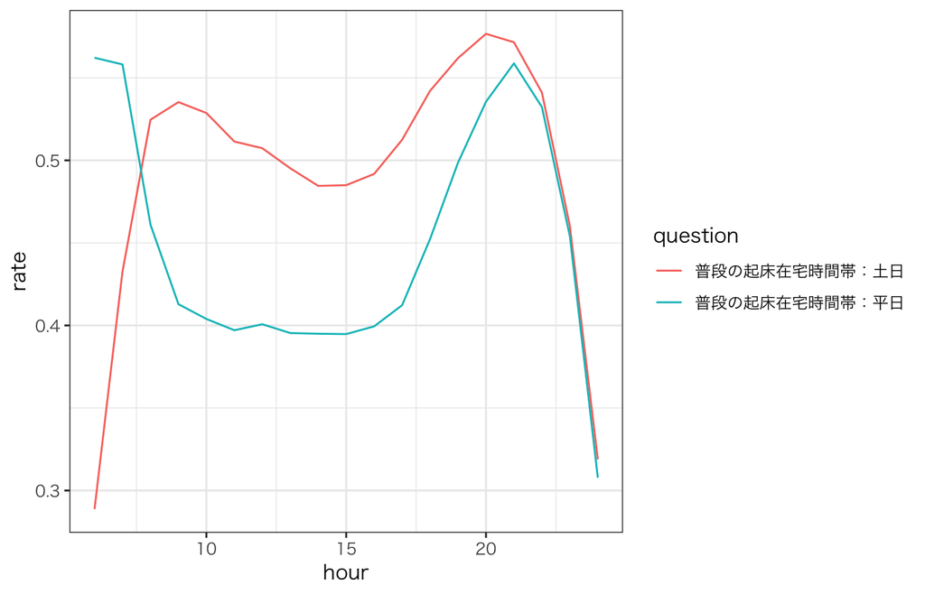

```r
data %>%
  filter(qu_genre_code == 2) %>%
  group_by(question) %>%
  mutate(count_house = length(unique(house_num))) %>%
  group_by(question, answer) %>%
  summarise(count = n(),
            rate = count / count_house[1]) %>%
  ungroup() %>%
  mutate(answer = as.integer(str_sub(answer, 1,-3))) %>%
  drop_na() %>%
  ggplot(aes(answer, rate, fill = question, colour = question))+
  geom_line()+
  labs(x = "hour")
```

```r
  # geom_bar(stat = "identity", position="identity", alpha = .7)+
  # facet_wrap(~question)
```